# Chap5. Visualization of factors

LEE EUN JU

### Library

```r
library(tidyverse)
library(gridExtra)
```

### Factors

**[categorical vs factor]**

factor은 ordertext variable, numeric categorical variable을 factor화 할 수 있으며 주로 bar graph를 사용하여 나타낸다.

[factor화]  
* is.numeric() #true, false -> numeric이면 TRUE, 아니면 FALSE  
* as.numeric() #numeric화

factor -> numeric : as.character() 후, as.numeric (바로 numeric으로 바꾸면 level로 바꾸는 것이다.)  
num/chr -> factor : 바로 as.factor

[factor의 ordering] : 중요!!  
[visualize facotr] : barchart (colour, fill, shape, facet 사용)

#### FBI data

```r
fbi<-read.csv('fbi.csv')
head(fbi)
```

```
##     State Abb Year Population                                 Type Count
## 1 Alabama  AL 1961    3302000 Murder.and.nonnegligent.Manslaughter   427
## 2 Alabama  AL 1962    3358000 Murder.and.nonnegligent.Manslaughter   316
## 3 Alabama  AL 1963    3347000 Murder.and.nonnegligent.Manslaughter   340
## 4 Alabama  AL 1964    3407000 Murder.and.nonnegligent.Manslaughter   316
## 5 Alabama  AL 1965    3462000 Murder.and.nonnegligent.Manslaughter   395
## 6 Alabama  AL 1966    3517000 Murder.and.nonnegligent.Manslaughter   384
##   Violent.crime
## 1          TRUE
## 2          TRUE
## 3          TRUE
## 4          TRUE
## 5          TRUE
## 6          TRUE
```

#### My turn

1. Inspect the fbi object. How many variables are there? Which type does each of the variables have?

```r
str(fbi)
```

```
## 'data.frame':    23672 obs. of  7 variables:
##  $ State        : chr  "Alabama" "Alabama" "Alabama" "Alabama" ...
##  $ Abb          : chr  "AL" "AL" "AL" "AL" ...
##  $ Year         : int  1961 1962 1963 1964 1965 1966 1967 1968 1969 1970 ...
##  $ Population   : int  3302000 3358000 3347000 3407000 3462000 3517000 3540000 3566000 3531000 3444165 ...
##  $ Type         : chr  "Murder.and.nonnegligent.Manslaughter" "Murder.and.nonnegligent.Manslaughter" "Murder.and.nonnegligent.Manslaughter" "Murder.and.nonnegligent.Manslaughter" ...
##  $ Count        : int  427 316 340 316 395 384 415 421 485 404 ...
##  $ Violent.crime: logi  TRUE TRUE TRUE TRUE TRUE TRUE ...
```

fbi의 변수는 총 7개로 각 변수들은 chr, int, logi(true/false)로 이루어져 있다. 이때, chr은 factor로 변형시켜주었다.

```r
fbi$State = as.factor(fbi$State)
fbi$Abb = as.factor(fbi$Abb)
fbi$Type = as.factor(fbi$Type)
str(fbi)
```

```
## 'data.frame':    23672 obs. of  7 variables:
##  $ State        : Factor w/ 52 levels "Alabama","Alaska",..: 1 1 1 1 1 1 1 1 1 1 ...
##  $ Abb          : Factor w/ 52 levels "AK","AL","AR",..: 2 2 2 2 2 2 2 2 2 2 ...
##  $ Year         : int  1961 1962 1963 1964 1965 1966 1967 1968 1969 1970 ...
##  $ Population   : int  3302000 3358000 3347000 3407000 3462000 3517000 3540000 3566000 3531000 3444165 ...
##  $ Type         : Factor w/ 8 levels "Aggravated.assault",..: 6 6 6 6 6 6 6 6 6 6 ...
##  $ Count        : int  427 316 340 316 395 384 415 421 485 404 ...
##  $ Violent.crime: logi  TRUE TRUE TRUE TRUE TRUE TRUE ...
```

factor은 level이 출력되는 것을 알 수있다.

2. Make a summary of Year

```r
summary(fbi$Year)
```

```
##    Min. 1st Qu.  Median    Mean 3rd Qu.    Max.
##    1961    1975    1990    1990    2004    2018
```

1961년부터 2018년까지의 데이터이다.

3. Make Year a factor variable: fbi`$`Year <- factor(fbi`$`Year)

```r
fbi$Year = factor(fbi$Year)
```

위에서 보았듯이 연산이 가능한 integer형태이므로 factor로 바꾸어 줄 필요가 있다.

4. Compare summary of Year to the previous result

```r
summary(fbi$Year)
```

```
## 1961 1962 1963 1964 1965 1966 1967 1968 1969 1970 1971 1972 1973 1974 1975 1976
##  400  400  400  400  400  408  408  408  408  408  408  408  408  408  408  408
## 1977 1978 1979 1980 1981 1982 1983 1984 1985 1986 1987 1988 1989 1990 1991 1992
##  408  408  408  408  408  408  408  408  408  408  408  408  408  408  408  408
## 1993 1994 1995 1996 1997 1998 1999 2000 2001 2002 2003 2004 2005 2006 2007 2008
##  408  408  408  408  408  408  408  408  408  408  408  408  408  408  408  408
## 2009 2010 2011 2012 2013 2014 2015 2016 2017 2018
##  408  408  408  408  416  416  416  416  416  416
```

```r
str(fbi)
```

```
## 'data.frame':    23672 obs. of  7 variables:
##  $ State        : Factor w/ 52 levels "Alabama","Alaska",..: 1 1 1 1 1 1 1 1 1 1 ...
##  $ Abb          : Factor w/ 52 levels "AK","AL","AR",..: 2 2 2 2 2 2 2 2 2 2 ...
##  $ Year         : Factor w/ 58 levels "1961","1962",..: 1 2 3 4 5 6 7 8 9 10 ...
##  $ Population   : int  3302000 3358000 3347000 3407000 3462000 3517000 3540000 3566000 3531000 3444165 ...
##  $ Type         : Factor w/ 8 levels "Aggravated.assault",..: 6 6 6 6 6 6 6 6 6 6 ...
##  $ Count        : int  427 316 340 316 395 384 415 421 485 404 ...
##  $ Violent.crime: logi  TRUE TRUE TRUE TRUE TRUE TRUE ...
```

factor로 변경 후 summary => count값  
1961년~2018 => factor로서 58개의 level이 존재한다.

5. **Are there other variables that should be factors (or vice versa)?**

   다른 변수는 factor가 될 필요가 없어 보인다.

#### factors in boxplots

```r
twoyear <- dplyr::filter(fbi, Year %in% c(1961, 2016))
head(twoyear)
```

```
##        State Abb Year Population                                 Type Count
## 1    Alabama  AL 1961    3302000 Murder.and.nonnegligent.Manslaughter   427
## 2     Alaska  AK 1961     234000 Murder.and.nonnegligent.Manslaughter    27
## 3    Arizona  AZ 1961    1391000 Murder.and.nonnegligent.Manslaughter    84
## 4   Arkansas  AR 1961    1797000 Murder.and.nonnegligent.Manslaughter   163
## 5 California  CA 1961   16397000 Murder.and.nonnegligent.Manslaughter   605
## 6   Colorado  CO 1961    1781000 Murder.and.nonnegligent.Manslaughter    83
##   Violent.crime
## 1          TRUE
## 2          TRUE
## 3          TRUE
## 4          TRUE
## 5          TRUE
## 6          TRUE
```

```r
str(twoyear)
```

```
## 'data.frame':    816 obs. of  7 variables:
##  $ State        : Factor w/ 52 levels "Alabama","Alaska",..: 1 2 3 4 5 6 7 8 9 10 ...
##  $ Abb          : Factor w/ 52 levels "AK","AL","AR",..: 2 1 4 3 5 6 7 9 8 10 ...
##  $ Year         : Factor w/ 58 levels "1961","1962",..: 1 1 1 1 1 1 1 1 1 1 ...
##  $ Population   : int  3302000 234000 1391000 1797000 16397000 1781000 2614000 458000 763956 5222000 ...
##  $ Type         : Factor w/ 8 levels "Aggravated.assault",..: 6 6 6 6 6 6 6 6 6 6 ...
##  $ Count        : int  427 27 84 163 605 83 25 20 88 477 ...
##  $ Violent.crime: logi  TRUE TRUE TRUE TRUE TRUE TRUE ...
```

- %in%: 1961년이거나 2016년일 때
- filter을 통해 2개의 level만을 선택

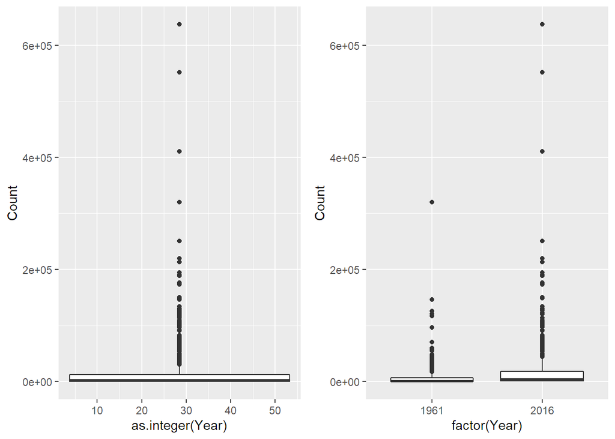

```r
ggplot(data=twoyear, aes(x=as.integer(Year),y=Count)) + geom_boxplot() -> p1 #x축이 58개의 level
ggplot(data=twoyear, aes(x=factor(Year),y=Count)) + geom_boxplot() -> p2
grid.arrange(p1,p2,nrow=1) #두개의 그래프 붙이는 것
```

p1 : x축이 58개의 integer로 설정되어 의도하고자 한 그림이 되지 않는다.  
p2 : factor화를 통해 1961년의 분포와 2016년의 분포를 볼 수 있다.  
* grid.arrange : 2개의 그래프를 한 번에 볼 수 있다.  
- nrow,ncol 옵션: 그림의 구조 설정(ex 2,2 -> 2행 2열 구조)

#### Reordering factor levels

levels() : factors의 종류

```r
levels(fbi$Type)
```

```
## [1] "Aggravated.assault"
## [2] "Burglary"
## [3] "Larceny.theft"
## [4] "Legacy.rape"
## [5] "Motor.vehicle.theft"
## [6] "Murder.and.nonnegligent.Manslaughter"
## [7] "Rape"
## [8] "Robbery"
```

지정한대로 reorder하는 경우

```r
fbi$Type = factor(fbi$Type, levels=c("Larceny.theft", "Burglary", "Motor.vehicle.theft", "Robbery" ,
                                     "Aggravated.assault", "Legacy.rape", "Rape", "Murder.and.nonnegligent.Manslaughter"))
```

변수(count)별 reorder -> reorder() 함수 이용  
* na.rm=TRUE 하지 않으면 모두 NA가 된다.

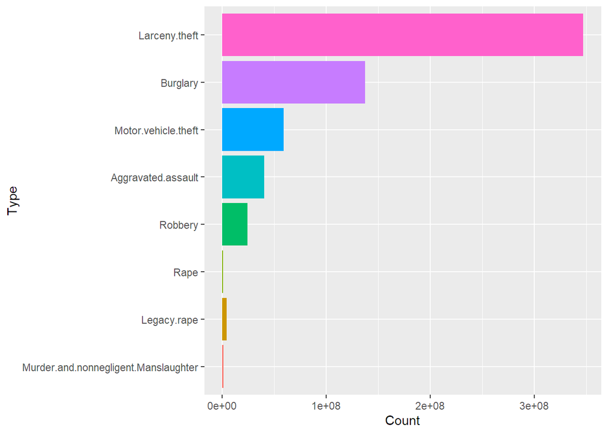

```r
fbi$Type = factor(fbi$Type, levels=levels(reorder(fbi$Type, fbi$Count, na.rm=TRUE)))
fbi %>%
  ggplot(aes(x=Type, y=Count, fill=Type)) +
  geom_bar(stat='identity', show.legend=FALSE) + coord_flip()  #geom_bar가 2개의 변수를 사용할 때 -> stat='identity'
```

#### My turn

Introduce a rate of the number of reported offenses by population into the fbi data. You could use the Ames standard to make values comparable to a city of the size of Ames (population ~70,000). Plot boxplots of crime rates by different types of crime. How can you make axis text legible? Reorder the boxplots of crime rates, such that the boxplots are ordered by their medians.(Hint: use reorder)

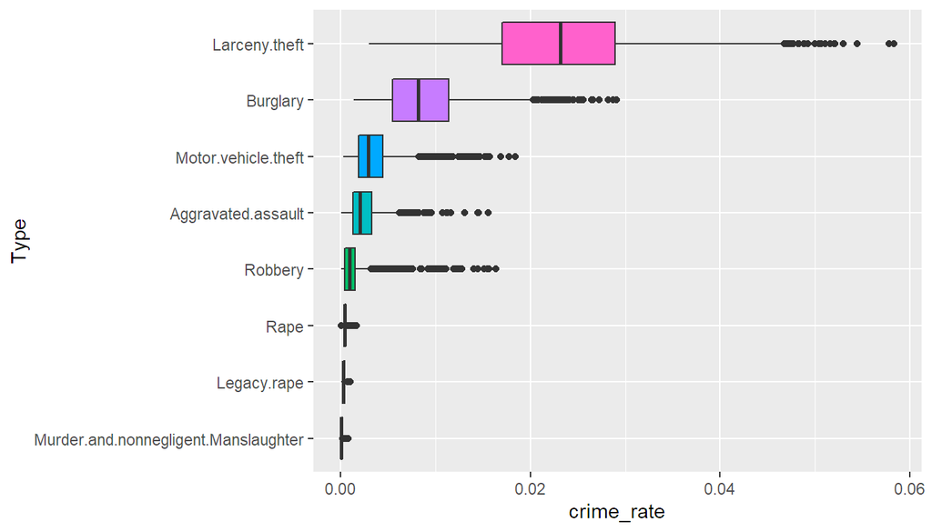

```r
fbi_rate = fbi %>%
  mutate(crime_rate = Count/Population)
fbi_rate %>%
  ggplot(aes(x=Type, y=crime_rate, fill=Type)) +
  geom_boxplot(show.legend=FALSE) + coord_flip()
```

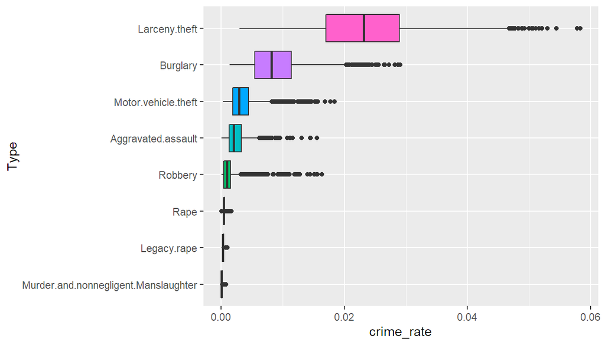

```r
#reorder(reorder하고자 하는 변수, 정렬기준이 되는 변수, 정렬기준에 적용시킬 function)
fbi_rate$Type = factor(fbi_rate$Type, levels=levels(reorder(fbi_rate$Type, fbi_rate$crime_rate, median, na.rm=TRUE)))
fbi_rate %>%
  ggplot(aes(x=Type, y=crime_rate, fill=Type)) +
  geom_boxplot(show.legend=FALSE) + coord_flip()
```

For one type of crime (subset!) plot boxplots of rates by state, reorder boxplots by median crime rates

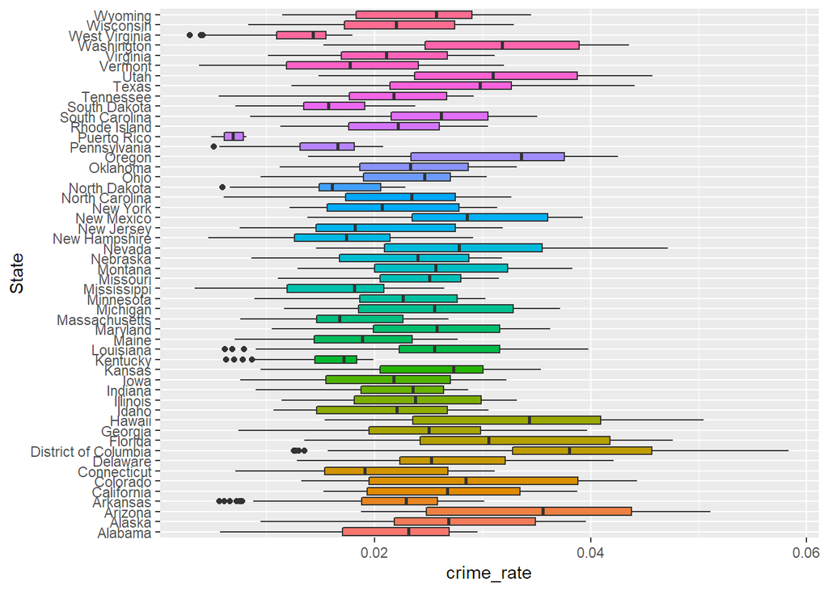

```r
fbi_rate %>%
  filter(Type == "Larceny.theft")%>%
  ggplot(aes(x=State, y=crime_rate, fill=State)) +
  geom_boxplot(show.legend=FALSE) + coord_flip()
```

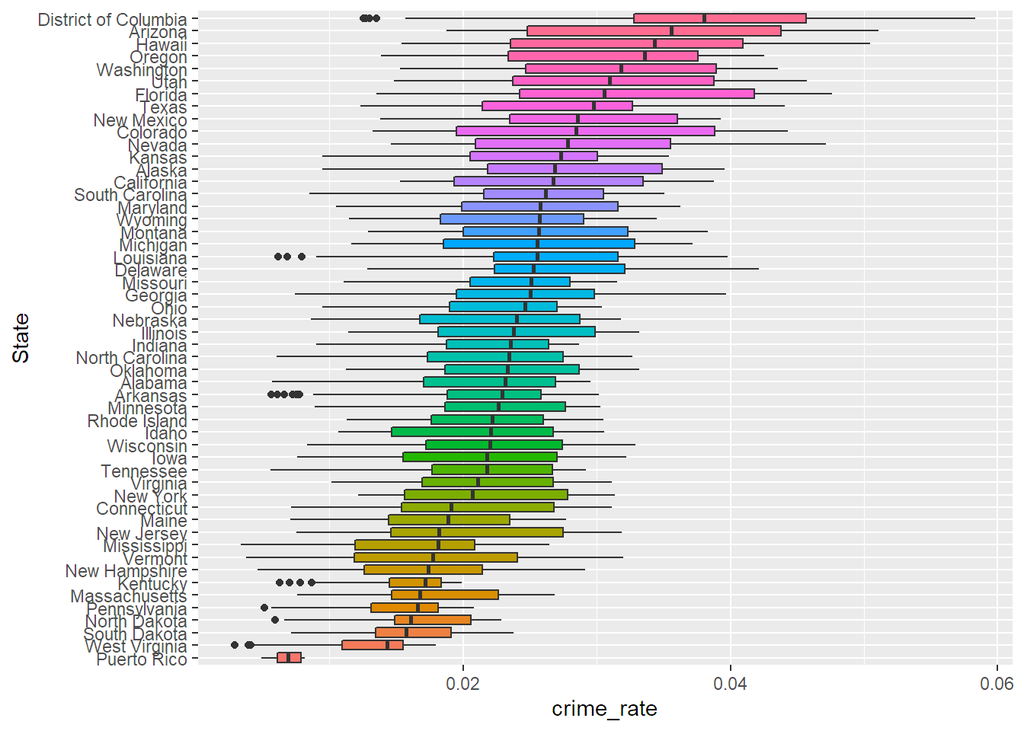

```r
#reorder
fbi_state = fbi_rate %>%
  filter(Type == "Larceny.theft")
fbi_state$State = factor(fbi_state$State, levels=levels(reorder(fbi_state$State, fbi_state$crime_rate, median, na.rm=TRUE)))

fbi_state %>%
  filter(Type == "Larceny.theft")%>%
  ggplot(aes(x=State, y=crime_rate, fill=State)) +
  geom_boxplot(show.legend=FALSE) + coord_flip()
```

#### Changing Level’s names

```r
levels(fbi$Type)
```

```
## [1] "Murder.and.nonnegligent.Manslaughter"
## [2] "Legacy.rape"
## [3] "Rape"
## [4] "Robbery"
## [5] "Aggravated.assault"
## [6] "Motor.vehicle.theft"
## [7] "Burglary"
## [8] "Larceny.theft"
```

```r
levels(fbi$Type)[6] <- "Murder"
levels(fbi$Type)
```

```
## [1] "Murder.and.nonnegligent.Manslaughter"
## [2] "Legacy.rape"
## [3] "Rape"
## [4] "Robbery"
## [5] "Aggravated.assault"
## [6] "Murder"
## [7] "Burglary"
## [8] "Larceny.theft"
```

#### Example

```r
fbi<-read.csv('fbi.csv')
fbi$State = as.factor(fbi$State)
fbi$Abb = as.factor(fbi$Abb)
fbi$Type = as.factor(fbi$Type)
str(fbi)
```

```
## 'data.frame':    23672 obs. of  7 variables:
##  $ State        : Factor w/ 52 levels "Alabama","Alaska",..: 1 1 1 1 1 1 1 1 1 1 ...
##  $ Abb          : Factor w/ 52 levels "AK","AL","AR",..: 2 2 2 2 2 2 2 2 2 2 ...
##  $ Year         : int  1961 1962 1963 1964 1965 1966 1967 1968 1969 1970 ...
##  $ Population   : int  3302000 3358000 3347000 3407000 3462000 3517000 3540000 3566000 3531000 3444165 ...
##  $ Type         : Factor w/ 8 levels "Aggravated.assault",..: 6 6 6 6 6 6 6 6 6 6 ...
##  $ Count        : int  427 316 340 316 395 384 415 421 485 404 ...
##  $ Violent.crime: logi  TRUE TRUE TRUE TRUE TRUE TRUE ...
```

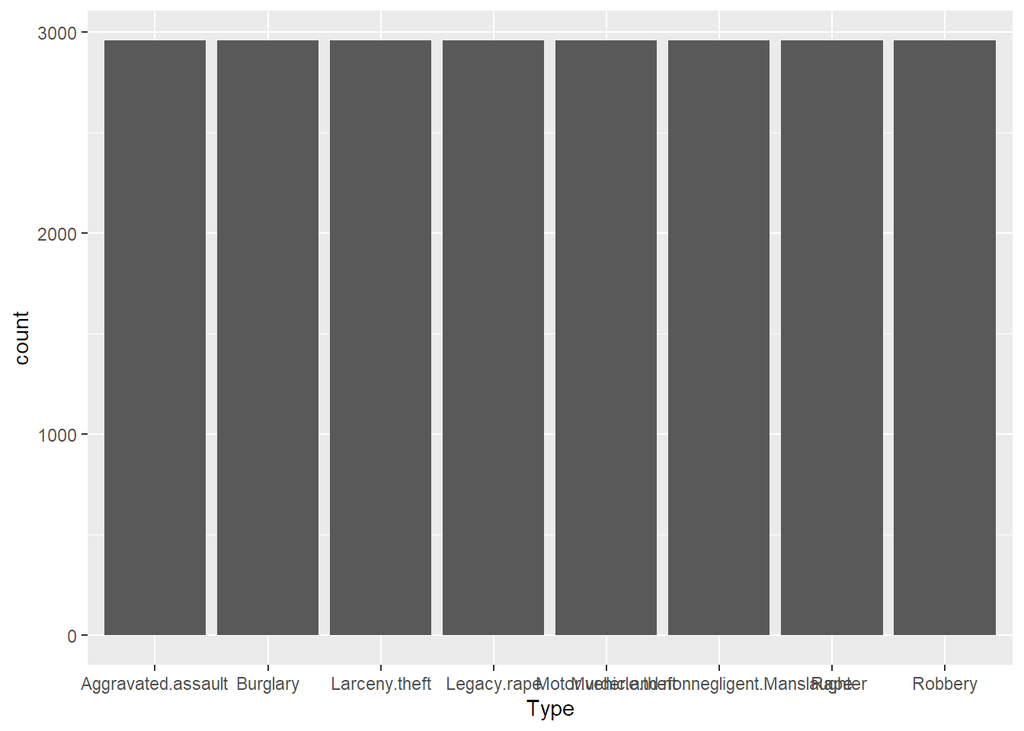

```r
ggplot(fbi, aes(x = Type, fill=Year)) + geom_bar()
```

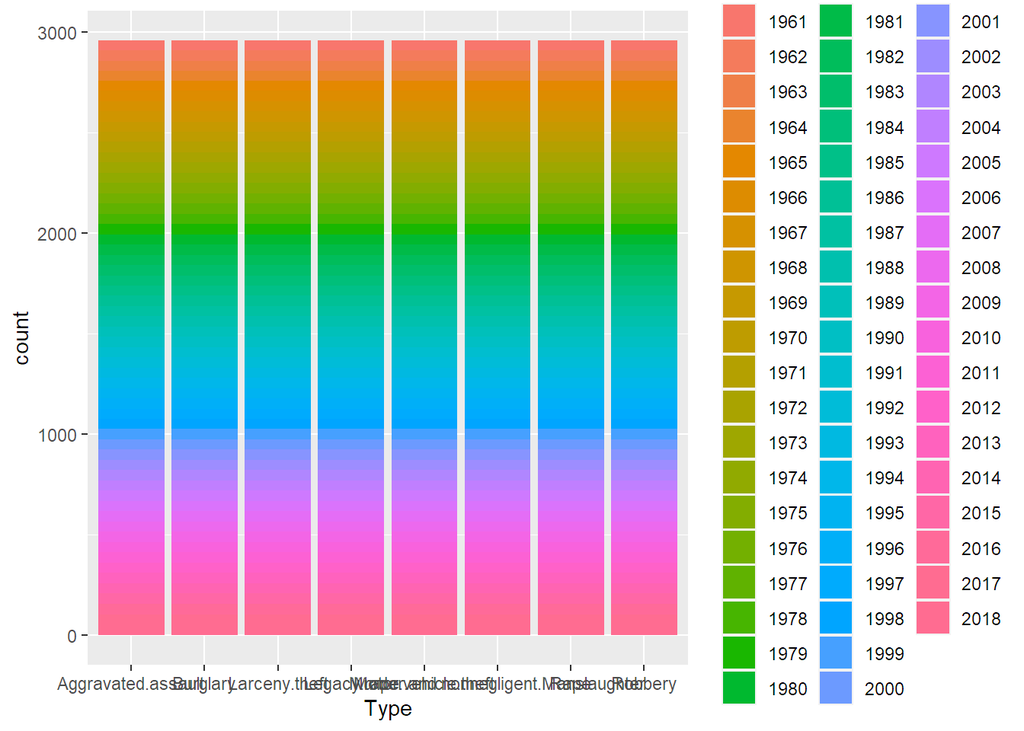

```r
ggplot(fbi, aes(x = Type, fill=factor(Year))) + geom_bar()
```

- #integer이므로 Year별 색깔 구분할 수 없다 => no color
- fill은 무조건 factor가 와야 한다.

#### Example2 : titanic data - 생존률에 관한 데이터(0:사망, 1:생존)

```r
library(titanic)
head(titanic_train)
```

```
##   PassengerId Survived Pclass
## 1           1        0      3
## 2           2        1      1
## 3           3        1      3
## 4           4        1      1
## 5           5        0      3
## 6           6        0      3
##                                                  Name    Sex Age SibSp Parch
## 1                             Braund, Mr. Owen Harris   male  22     1     0
## 2 Cumings, Mrs. John Bradley (Florence Briggs Thayer) female  38     1     0
## 3                              Heikkinen, Miss. Laina female  26     0     0
## 4        Futrelle, Mrs. Jacques Heath (Lily May Peel) female  35     1     0
## 5                            Allen, Mr. William Henry   male  35     0     0
## 6                                    Moran, Mr. James   male  NA     0     0
##             Ticket    Fare Cabin Embarked
## 1        A/5 21171  7.2500              S
## 2         PC 17599 71.2833   C85        C
## 3 STON/O2. 3101282  7.9250              S
## 4           113803 53.1000  C123        S
## 5           373450  8.0500              S
## 6           330877  8.4583              Q
```

```r
?titanic_train
```

```
## starting httpd help server ... done
```

1. barcharts of all variables

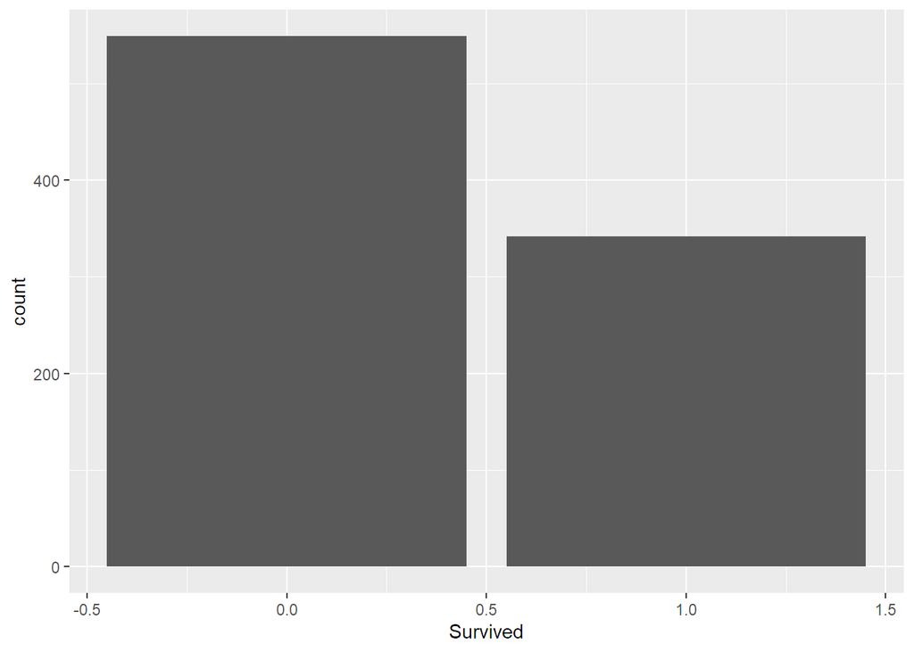

```r
ggplot(titanic_train, aes(x = Survived)) +geom_bar()
```

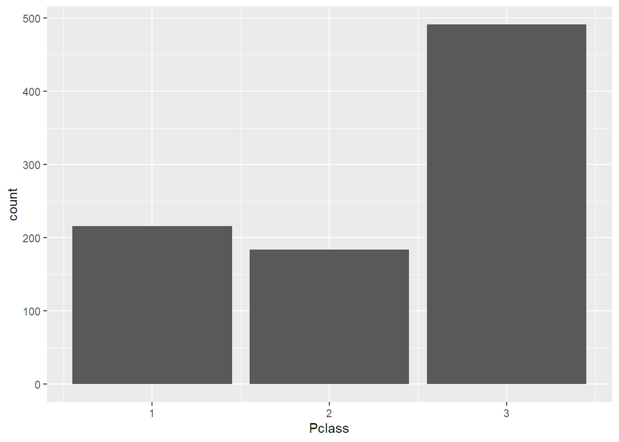

```r
ggplot(titanic_train, aes(x = Pclass))+geom_bar()
```

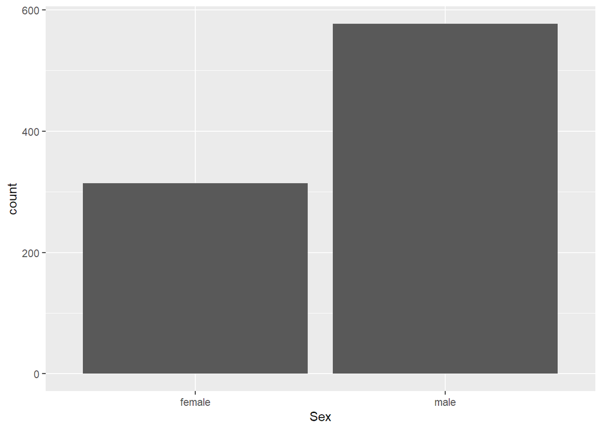

```r
ggplot(titanic_train, aes(x = Sex))+geom_bar()
```

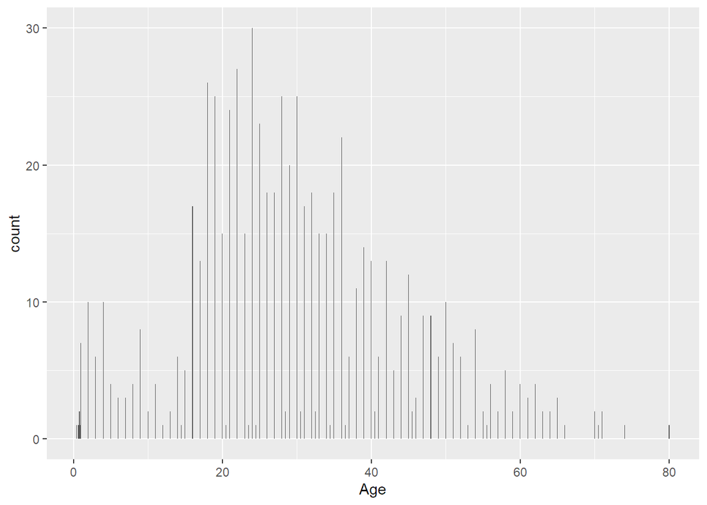

```r
ggplot(titanic_train, aes(x = Age))+geom_bar()
```

#position=“fill” : 비율100%로 , 상대적 비교가 필요할 때 사용

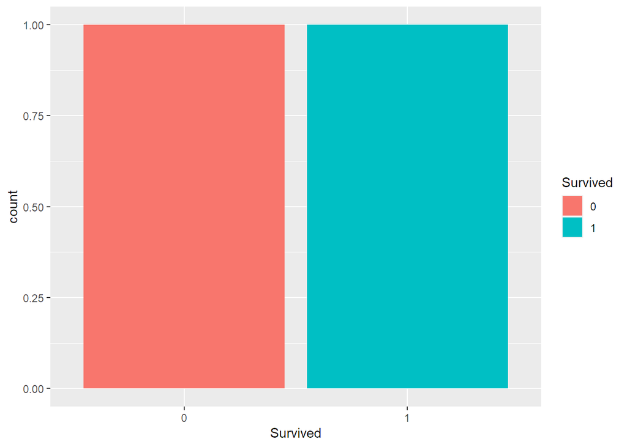

```r
titanic_train$Survived <- factor(titanic_train$Survived)
ggplot(titanic_train, aes(x = Survived, fill=Survived)) + geom_bar(position="fill")
```

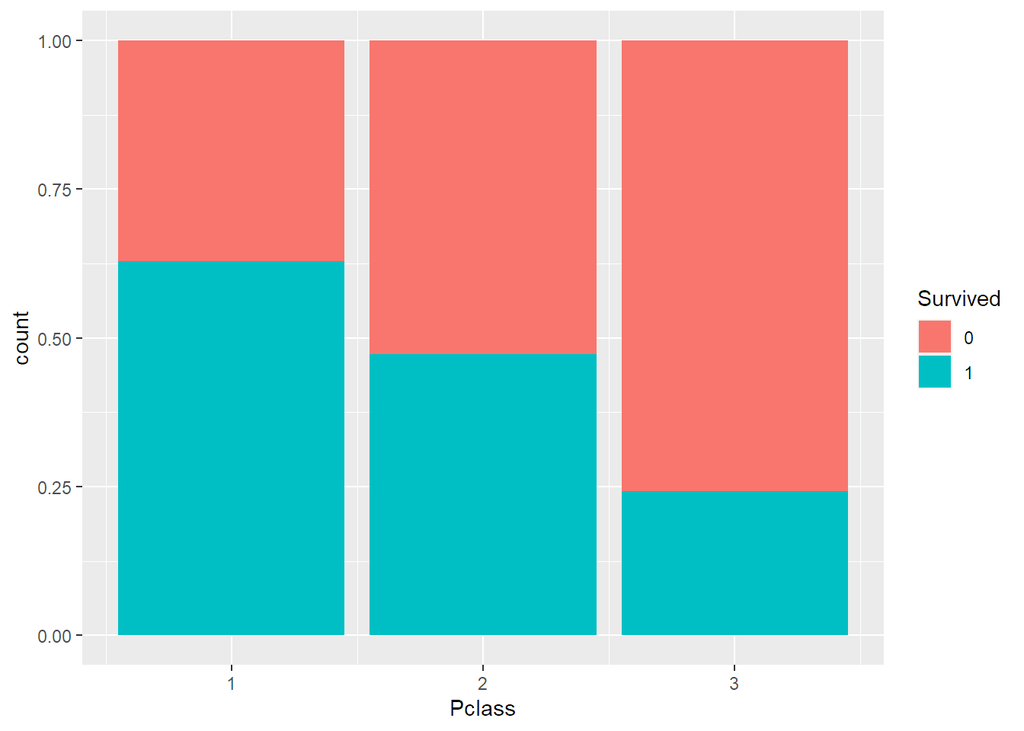

```r
ggplot(titanic_train, aes(x = Pclass, fill=Survived)) + geom_bar(position="fill")
```

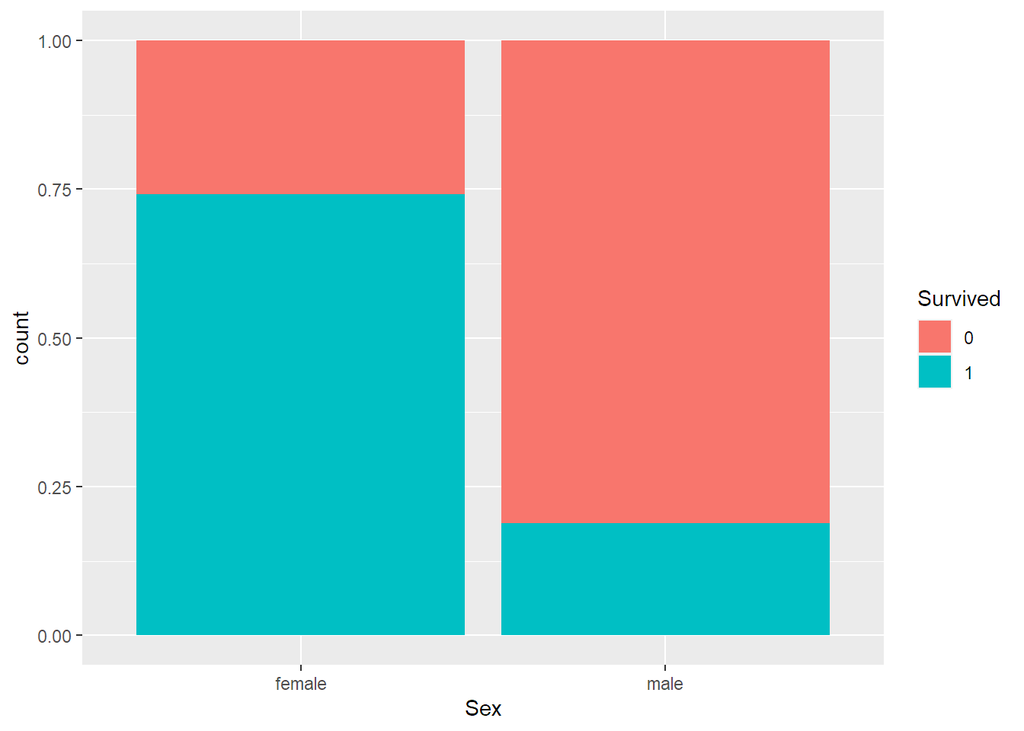

```r
ggplot(titanic_train, aes(x = Sex, fill=Survived)) + geom_bar(position="fill")
```

2. Two and more factor variables(geom_mosaic)
- product : list별로 묶어주는 역할을 한다 => geom_mosaic할때, product한 후 설정
- weight : stat_count()를 의미한다.

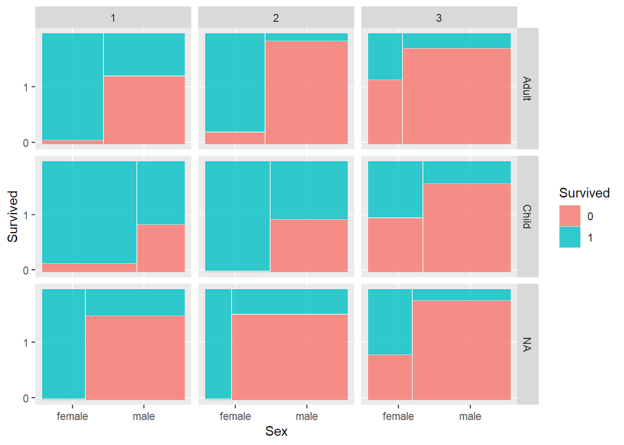

```r
library(ggmosaic)
titanic_train %>%
  mutate(Age2=ifelse(Age>20, 'Adult', 'Child')) %>%
  ggplot() +
  geom_mosaic(aes(x = product(Sex), fill=Survived, weight=1)) +
  facet_grid(Age2~Pclass)
```

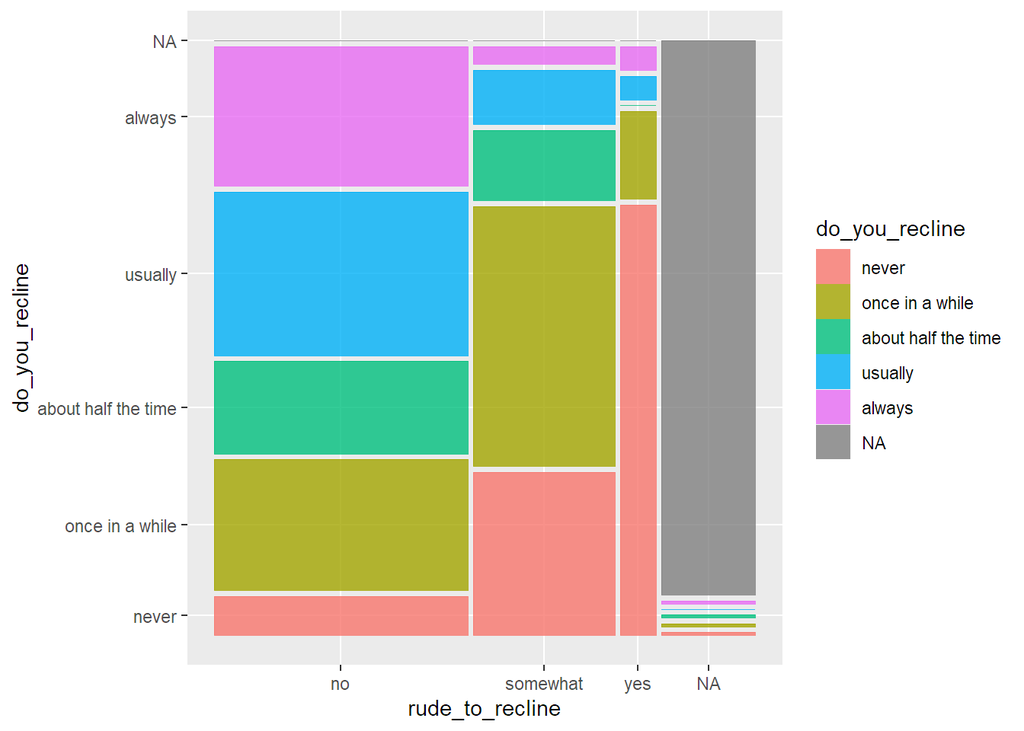

```r
ggplot(data= fly) + geom_mosaic(aes(x = product(rude_to_recline), fill = do_you_recline ))
```

- 하나의 변수일 때

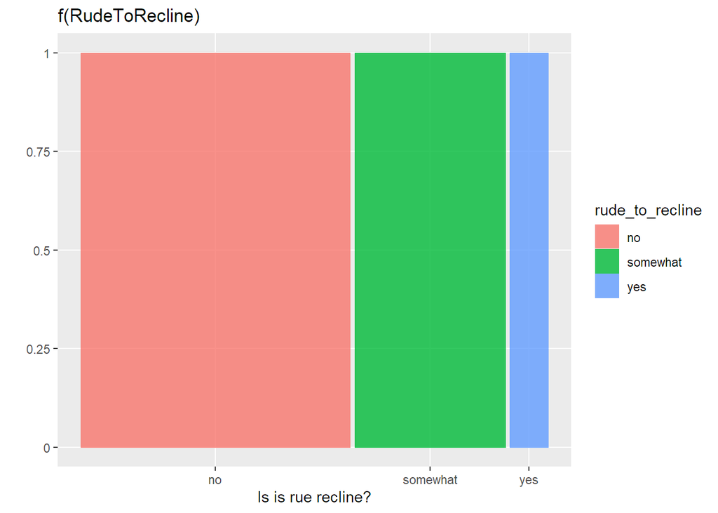

```r
fly %>%
  filter(!is.na(rude_to_recline)) %>%
  ggplot() + geom_mosaic(aes(x = product(rude_to_recline), fill = rude_to_recline )) +
  labs(x="Is is rue recline?", title="f(RudeToRecline)")
```

- 1 ~ X+Y

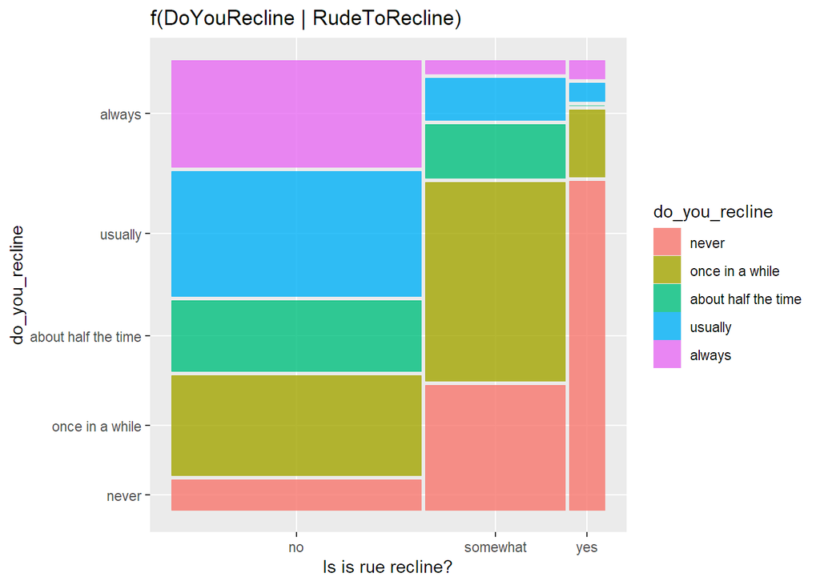

```r
fly %>%
  filter(!is.na(rude_to_recline)) %>%
  ggplot() + geom_mosaic(aes(x = product(do_you_recline, rude_to_recline), fill = do_you_recline )) +
  labs(x="Is is rue recline?", title="f(DoYouRecline | RudeToRecline)")
```

- 1 ~ X+Y/Z

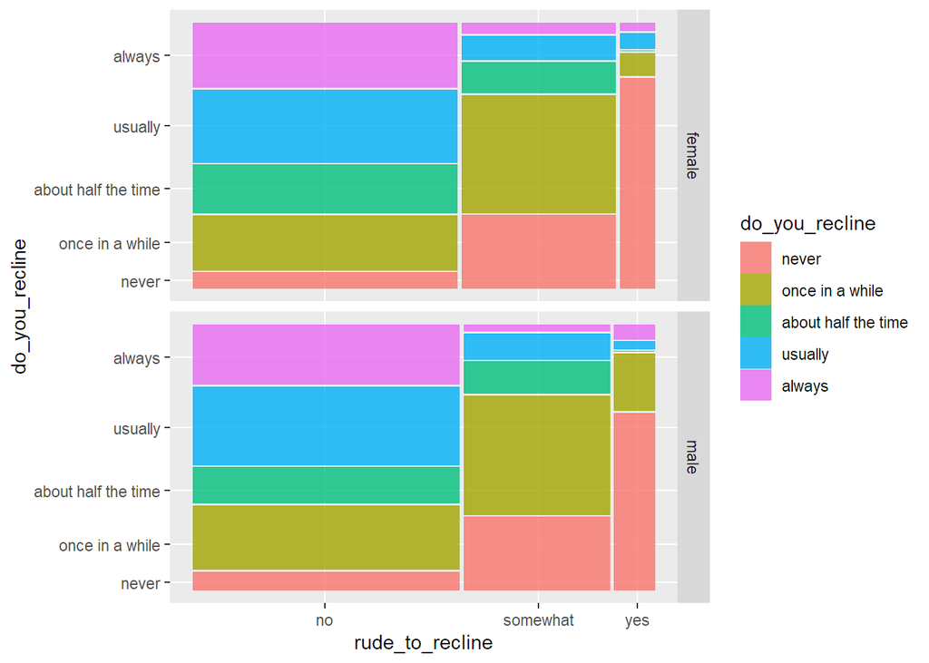

```r
fly %>%
  filter(!is.na(rude_to_recline), !is.na(gender)) %>%
  ggplot() + geom_mosaic(aes(x = product(do_you_recline, rude_to_recline), fill=do_you_recline)) +
  facet_grid(gender~.)
```

#### My turn

1. Draw a barchart of Gender. Interpret.

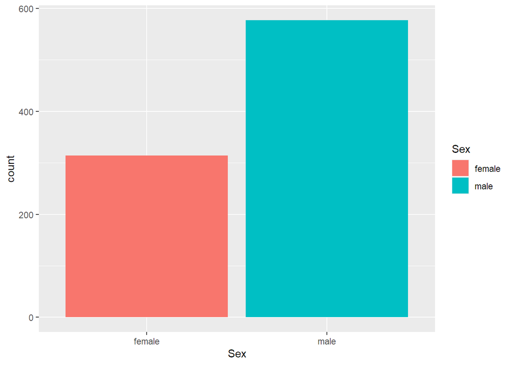

```r
titanic_train %>%
  ggplot() +
  geom_bar(aes(Sex, fill=Sex))
```

타이타닉호에 남성이 많이 타고 있음을 알 수 있다.

2. Map survival to fill color in the barchart of Gender. Interpret.

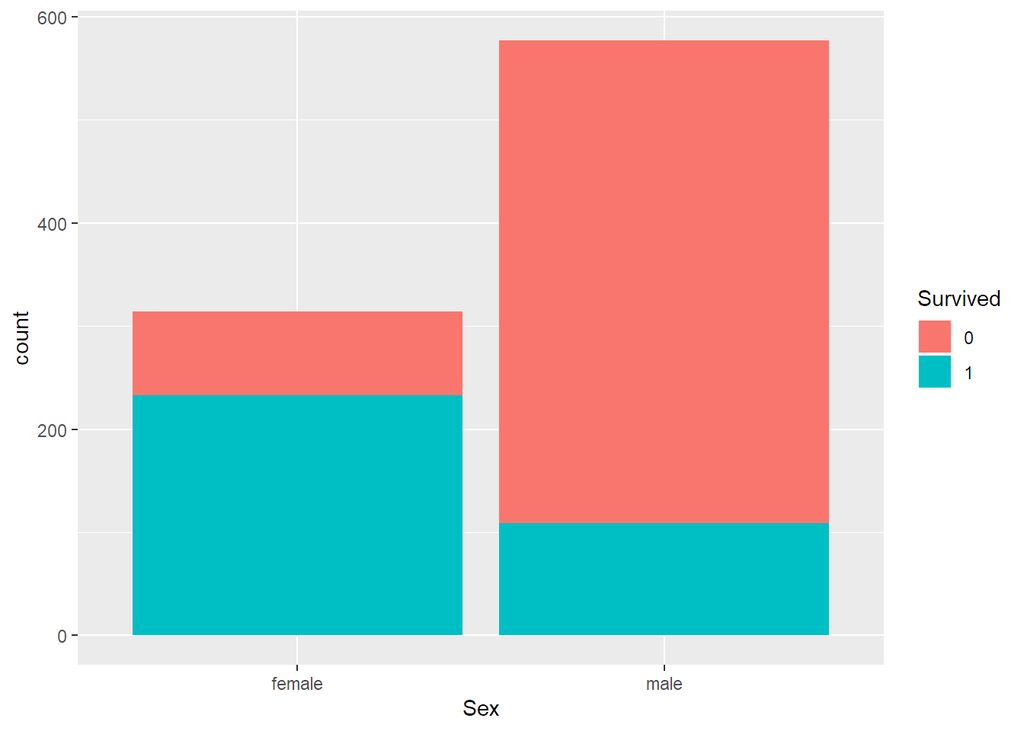

```r
titanic_train %>%
  ggplot() +
  geom_bar(aes(x=Sex, fill=Survived))
```

남성이 훨씬 많이 타고 있었음에도 여성이 훨씬 많이 생존하였다.

3. In the previous barchart change the position parameter to “fill”.Interpret.

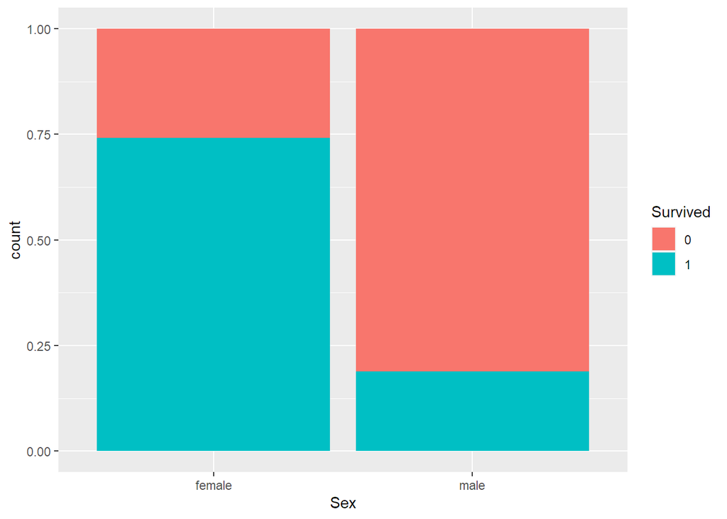

```r
titanic_train %>%
  ggplot() +
  geom_bar(aes(x=Sex,fill=Survived),position="fill")
```

position=“fill”을 통해 상대적으로 생존한 비율을 알 수 있다.

4. Read up on the position parameter in ?geom_bar. Try out other options for position.

```r
?geom_bar
```

position = dodge : 데이터의 종류를 나눠 옆에 따로 표시 position = stack : 위로 쌓아 누적 막대 그래프 position = identity : 위치조정을 적용하지 않고 그래프를 겹친다 position = jitter : 연속형자료에서 주로 사용하며 값들이 겹치지 않도록 조금씩 움직임